# Week07_Friday slides

## Announcements

1. **SPRING BREAK*

## Goals

1. Class exercise on *forward* kinematics
2. Class exercise on *inverse* kinematics (two parts)

## In-Class Exercise 1: ArtyBot Foward Kinematics

**Your task is to *validate* our model of Forward Kinematics (FK). You can use the "easy" solution that only involves trig, or (and much more importantly) you can use the *general* approach that leverages homogeneous transformations.**

- **GOAL:** Write a function that produces and estimate of $^A\vec{P}$ based on $\theta_2,\theta_3$**

Note that on the "real" ArtyBot, a servo command of "90 degrees" (mid range) for $\theta_2,\theta_3$ results in the following configuration:

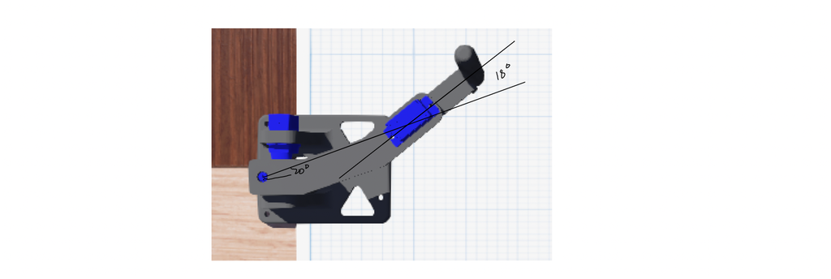

.

.

.

.

.

.

## In-Class Exercise 2: ArtyBot Inverse Kinematics

In the ArtyBot webots world, implement the inverse kinematic equations we derived in class.

1. Draw a box using ArtyBot
2. Build a FSM and program to draw any arbitrary shape separated by lists of points in the XY (allocentric) plane using Arty. Program should read a text file that describes what it needs to draw. ○ File should have 3 columns: Drawing (boolean), X (m) Y (m) ○ FSM should lift pen if "Drawing" column contains a 0, and should place pen on paper when "Drawing" column contains a 1.

**HINTS for exercise 2.1**

- Above the loop:
  - define a box by xy points (an array)
    - points = np.array([[.08, 0],[.08,.02],[.1,0.02],[.1,0.0]])
    - Define a "box point index" variable starting at 0 that you will increment to draw the "next" point in your array.
  - Define a FSM timer that represents how long to "dwell" on any one commanded point. Don't need a whole FSM for exercise 1, but you will for exercise 2.
- In the loop:
  - Update timer so that it's enabled if its status bit isn't true. This will create an "auto-firing" timer that continuously resets itself at a known interval
  - When the timer status bit goes true, increment the "box point index" variable by 1
  - If you've gone through all the points, reset this index to 0.
  - Now use your IK formula to find theta1, theta2
  - Now convert theta1,theta2 to servo angles
  - Then send servo angles to robot.
  - Plot GPS pen position and "box points" together